# Random Forests: Tree Ensembles

Alípio Jorge

March 2021

# Another Ensemble approach (for trees)

- **Bagging**
  - Ensemble of decision trees from **bootstrapped** samples
  - **Reduces variance**
  - Can be used with other models, but is very adequate for trees
  - Learning trees is **relatively fast**, so boosting is not a very heavy approach

# Another Ensemble approach (for trees)

- Random Forest
  - Similar to bagging
  - Samples data **and variables**
  - Also designed for trees
    - But the principle is general
  - Tends to be **superior** to bagging (in general, always **validate empirically**)

  $$ Error(Bagging) > Error(Random~Forest) $$

[figure not shown]

```python
from IPython.display import Image
Image("imagens/NeuralRandomForests.png")
```

# Random Forests > Overall idea

- The Random Forest approach
  - Build an Ensemble of trees from dataset $D$ with $N$ cases and $p$ predictors
  - At each **iteration** $i = 1, \ldots, M$
    - Obtain a **bootstrap** $S_i$ sample from $D$
    - Learn a tree $T_i(x)$ from $S_i$ using $m$ **Randomly** selected predictors
      - using $m$ **Randomly** selected predictors at each split, $m<p$
- The final model in regression is $$ \hat{f}_{RF}(x) = \frac{1}{M}\sum_{i=1}^{M} T_i(x) $$
- In classification, the decision is by **majority vote**

# Random Forests > Why?

- Selecting a **subset** of the variables?
  - What if the **best predictor** is not included?
- In Bagging, a very strong predictor will top **all trees**
  - Averaging highly correlated models has a **smaller effect on variance**
- In RandomForests **weaker predictors** also have a say
  - This **reduces correlation** between trees

# Random Forest vs Bagging

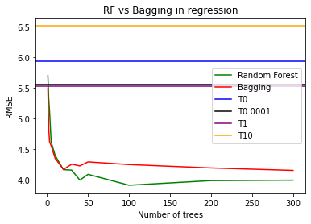

```python
from sklearn.tree import DecisionTreeRegressor as DTR
from sklearn.ensemble import BaggingRegressor as BagR
from sklearn.ensemble import RandomForestRegressor as RFR
from sklearn.datasets import load_boston
from sklearn.model_selection import cross_val_score
import matplotlib.pyplot as plt
import numpy as np

data = load_boston()
X=data.data
y=data.target

RFfeat=np.int(X.shape[1]/3) # advised for regression
nfolds=10

ntree=np.array([1,2,3,5,10,20,30,40,50, 100, 200,300])

def score_tree(c):
    tree=DTR(ccp_alpha=c)
    return np.mean(-cross_val_score(tree,X,y,cv=nfolds,scoring='neg_root_mean_squared_error'))

def score_rf(nt):
    treerf=RFR(n_estimators=nt, max_features=RFfeat)
    return np.mean(-cross_val_score(treerf,X,y,cv=nfolds,scoring='neg_root_mean_squared_error'))

def score_bag(nt):
    treebag=BagR(n_estimators=nt)
    return np.mean(-cross_val_score(treebag,X,y,
                                    cv=nfolds,scoring='neg_root_mean_squared_error',
                                    ))

error_rf = list(map(score_rf,ntree))
error_bag = list(map(score_bag,ntree))

error_t = [score_tree(0),
           score_tree(0.0001),
           score_tree(1),
           score_tree(10)]

plt.plot(ntree,error_rf,color='green')
plt.plot(ntree,error_bag,color='red')
tree_colors=['blue','black','purple','orange']
for i in range(4):
    plt.axhline(error_t[i],color=tree_colors[i])

plt.legend(['Random Forest','Bagging','T0','T0.0001','T1','T10'])
plt.xlabel('Number of trees')
plt.ylabel('RMSE')
plt.title('RF vs Bagging in regression');
```

# Random forests and overfitting

- Random Forests can overfit
  - But they are relatively safe
- Random Forest with unpruned trees gives good results
  - Trees are limited by number of features

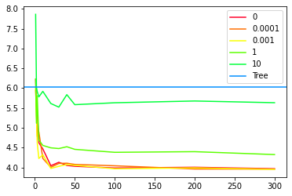

```python
import matplotlib.pyplot as plt

n = 10
colors = plt.cm.gist_rainbow(np.linspace(0,1,n))

def score_rf_depth(nt,ccp):
    treerf=RFR(n_estimators=nt, max_features=RFfeat, ccp_alpha=ccp)
    return np.mean(-cross_val_score(treerf,X,y,cv=nfolds,scoring='neg_root_mean_squared_error'))

ccps=[0,0.0001,0.001,1,10]

error_rf_ccp=[0]*len(ccps)

for i in range(len(ccps)):
    error_rf_ccp[i]= list(map(lambda n:score_rf_depth(n,ccps[i]),ntree))
    plt.plot(ntree,error_rf_ccp[i],color=colors[i])

error_t = score_tree(0.0001)

plt.axhline(error_t,color=colors[len(ccps)+1])
plt.legend(ccps+['Tree'])
```

# Random Forests > Why?

- In RF it is **advised** to use
  - $m = \lfloor \sqrt{p} \rfloor$ predictors for **classification**
  - $m = \lfloor p/3 \rfloor$ for **regression**
- **Most trees** will not have the best predictor at the top
- Analogy
  - A committee of experts are analyzing an object on a table
  - Bagging: experts have **similar view points** (all at one end of the table)
  - Random Forest: experts have **diverse view points** (all around the table)

# Random Forest > into the woods

- Like in Bagging, the trees are **identically distributed**
- Variance reduces with the number of trees in Bagging or Random Forests
  - Assuming we have no correlation (trees are independent):

    $$ \mathrm{var}_{i.i.d.} = \frac{1}{M}\sigma^2 $$
- But if the trees are not independent, having pairwise correlation $\rho$

  $$ \mathrm{var}_{i.d.} = \rho\sigma^2 + \frac{1-\rho}{M}\sigma^2 $$
  - Even if $M$ grows $\rho\sigma^2$ **does not reduce**
- Random Forest **reduces** $\rho$ by sampling predictors

# Random Forest > into the woods

- Why trees?
  - Non-linear estimators benefit from this "data shaking"
  - Trees tend to have low correlation
  - Linear models have **higher** correlation
  - Trees are fast to learn
  - Trees are easy to parameterize

# Random Forest > pros and cons

- The **advantages** of RF
  - Good predictive ability
  - Better than Bagging
  - Easy **parameter choice**
    - Do not tend to overfit
    - But `mtry` can be tricky
- The **disadvantages** of RF
  - Interpretability (like Bagging)
  - **Boosting** (next) can beat RF with good parameters

# OOB > Out of Bag Estimation

- What is an **OOB** estimator?
  - Pick an observation $z_i = (x_i, y_i)$
  - Take the trees learned in bags **without** $z_i$
  - Predict $y_i$
- At each iteration, we can
  - Estimate the OOB error
  - **During** learning
- **OOB** is a very practical tool for **monitoring** learning
  - Computationally cheap
  - It can be a useful estimate (e.g. for tuning number of trees)
  - But, it can be **optimistic**
  - Does **not replace** cross-validation

# OOB > Out of Bag Estimation

Let us compare the OOB estimate with the holdout estimate.

- Note that plotting 200 points for the holdout estimate is quite expensive
  - quadratic with the number of trees (why)

```python
from sklearn.metrics import mean_squared_error as MSE

treerf=RFR(n_estimators=300, max_features=RFfeat, oob_score=True).fit(X,y)
ypred=treerf.oob_prediction_

np.sqrt(MSE(y,ypred))
```

```
3.1166094094548074
```

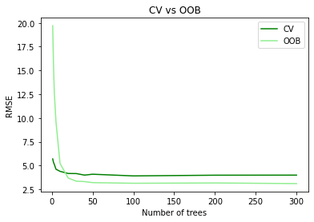

```python
def oob_score_rf(nt):
    treerf=RFR(n_estimators=nt, max_features=RFfeat, oob_score=True).fit(X,y)
    ypred=treerf.oob_prediction_
    return np.sqrt(MSE(y,ypred))

def oob_score_bag(nt):
    treebag=BagR(n_estimators=nt, oob_score=True).fit(X,y)
    ypred=treebag.oob_prediction_
    return np.sqrt(MSE(y,ypred))


#ntree=np.array([1,2,3,5,10,20,30,40,50, 100, 200,300])

error_rf_oob=list(map(oob_score_rf,ntree))
plt.plot(ntree,error_rf,color='green')
plt.plot(ntree,error_rf_oob,color='lightgreen')
plt.legend(['CV','OOB'])
plt.xlabel('Number of trees')
plt.ylabel('RMSE')
plt.title('CV vs OOB');
```

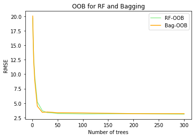

```python
def oob_score_bag(nt):
    treebag=BagR(n_estimators=nt, oob_score=True).fit(X,y)
    ypred=treebag.oob_prediction_
    return np.sqrt(MSE(y,ypred))

error_bag_oob=list(map(oob_score_bag,ntree))

plt.plot(ntree,error_rf_oob,color='lightgreen')
plt.plot(ntree,error_bag_oob,color='orange')
plt.legend(['RF-OOB','Bag-OOB'])
plt.xlabel('Number of trees')
plt.ylabel('RMSE')
plt.title('OOB for RF and Bagging');
```

# Variable Importance

- **Variable importance** can be measured in many **different** ways
- Typically:
  - **Sum** the improvements of each variable in a tree
  - **Average** over the trees
- Improvement
  - Increase in $R^2$
  - Reduction of *Gini*
  - Other spliting criterion
- **Plot** variable importance

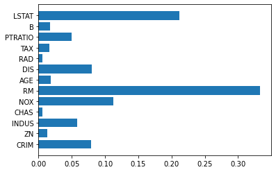

```python
treerf=RFR(n_estimators=20, max_features=RFfeat).fit(X,y)

feat_imp=treerf.feature_importances_
feat_names=data.feature_names

plt.barh(feat_names,feat_imp);
```

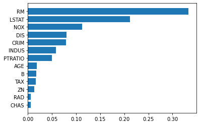

```python
feat_idx = np.argsort(feat_imp)
plt.barh(feat_names[feat_idx],feat_imp[feat_idx]);
```

# Activities

1. Compare Boosting, Bagging and Random Forest on Boston
   - Plot the error of Random Forest for different values of `mtry`
   - Are the recommended values for mtry the best?
   - Plot the error of Random Forest for different tree sizes
2. Pick a different dataset and do the same
3. Plot the boundaries of Random Forest vs knn
   - use an artificial two class, two predictors dataset (easy to visualize)

# Bibliography

- The Elements of Statistical Learning. Hastie, Trevor, Tibshirani, Robert, Friedman, Jerome. Springer 2012. (chapter 15)
- An Introduction to Statistical Learning - with applications in R G. James, D. Witten, T. Hastie, R. Tibshirani, Springer 2013.